# Probability & Random Variables

SPEA V706 · Math Camp · Day 1

Coady Wing

## The Plan

- Vocabulary of chance: sample space, outcomes, events, probability function
- Joint and conditional probability, independence, and Bayes’ rule
- Random variables and their distributions
- Reading: Hansen, *Probability and Statistics for Economists*, chapters 1–2

## Chance Experiments and Probability

## A Chance Experiment

A **chance experiment** is a situation whose outcome is not settled in advance.

- a coin flip
- a roll of the dice
- the age of a randomly chosen worker
- which of 500 applicants gets audited

## The Sample Space

An **outcome** is one possible result of the experiment.

The **sample space** is the set of all possible outcomes.

- Use $\Omega$ to represent the sample space
- $\omega \in \Omega$ is one particular outcome

For a 6-sided die, the sample space is $\Omega = \{1, 2, 3, 4, 5, 6\}$.

## Events

An **event** is a subset of the sample space.

Roll a six-sided die:

- $A = \{2, 4, 6\}$ is the event “roll an even number”
- $B = \{2\}$ is the event “roll a two”

## Unions, Intersections, and Complements

- Union: $A \cup B$ is the set of outcomes that belongs to event A, or event B, or both A and B.
- Intersection: $A \cap B$ is the set of outcomes that belong to both event $A$ and event $B$
- Complement: $A^c$ is the set of outcomes that do not belong to event $A$”

## Examples: Unions, Intersections, and Complements

Suppose the sample space is $\{1, 2, 3, 4, 5, 6\}$.

Event $A = \{1, 2, 3\}$

Event $B = \{2, 3, 4\}$.

- Union: $A \cup B = \{1, 2, 3, 4\}$
- Intersection: $A \cap B = \{2, 3\}$
- Complement: $A^c = \{4, 5, 6\}$

## The Probability Function

$\Pr(A)$ is a function that maps the sample space to the real number line, with the following properties:

- $0 \le \Pr(A) \le 1$
- $\Pr(\Omega) = 1$ and $\Pr(\varnothing) = 0$
- $\Pr(A \cup B) = \Pr(A) + \Pr(B)$ when $A$ and $B$ are disjoint
- If A and B are not disjoint, then: $\Pr(A \cup B) = \Pr(A) + \Pr(B) - \Pr(A \cap B)$.

## What does a probability mean?

Frequentist: If you repeat the chance experiment (roll the die) many times, then $\Pr(A)$ is the fraction of times that event $A$ occurs after many repetitions.

Bayesian: $\Pr(A)$ represents your degree of belief that event $A$ will occur, based on the available evidence.

## Some examples of probabilities – games of chance

- The probability of rolling a 6 on a fair 6-sided die is $\frac{1}{6}$
- The probability of a drawing a red card from a standard deck of 52 cards is $\frac{26}{52} = \frac{1}{2}$
- The probability of rolling a sum of 7 on two fair 6-sided dice is $\frac{6}{36} = \frac{1}{6}$

## Some examples of probabilities – real world

- Use $j=1...N$ to index the set of newly enrolled undergraduate students at Indiana University in 2026.
- Suppose that $GPA_j$ is student $j$’s high school GPA.
- Suppose we randomly select 1 student from the N newly enrolled students.
  - What is the probability that the selected student has a high school GPA above 3.5?
  - What is the probability that the selected student will graduate in 4 years?

## Joint and Conditional Probability

$\Pr(A \cap B)$ is the joint probability that both $A$ and $B$ occur.

$\Pr(A \mid B)$ is the conditional probability of $A$, given that $B$ has occurred.

Conditional probability is defined as:

$$\Pr(A \mid B) = \frac{\Pr(A \cap B)}{\Pr(B)}
\qquad \text{for } \Pr(B) > 0$$

- The denominator renormalizes: $B$ is the new sample space and we ask what fraction of the $B$ outcomes are also in $A$?

## Joint and Conditional Probability – Example

What is the probability that a student will graduate in 4 years, given that they have a high school GPA above 3.5?

## The Multiplication Rule and Independence

Rearrange the conditional probability definition to get the **multiplication rule**:

$$\Pr(A \cap B) = \Pr(A \mid B)\,\Pr(B)$$

$A$ and $B$ are **independent** when learning $B$ tells you nothing about $A$:

$$\Pr(A \mid B) = \Pr(A)
\qquad \Longleftrightarrow \qquad
\Pr(A \cap B) = \Pr(A)\,\Pr(B)$$

## Bayes’ Rule

Suppose you know $\Pr(B \mid A)$ but you want to know $\Pr(A \mid B)$?

Write the conditional probability, then substitute the multiplication rule in the numerator:

$$\begin{align*}
\Pr(A \mid B) &= \frac{\Pr(A \cap B)}{\Pr(B)} \\[4pt]
&= \frac{\Pr(B \mid A)\,\Pr(A)}{\Pr(B)}
\end{align*}$$

## Bayes’ Rule at Work

When she is 51 years old, Asha has a routine screening mammogram. Her doctor’s office calls her back for additional evaluation because the mammogram result is positive.

Given that she tested postive on the mammogram, what is the probability that Asha actually has breast cancer?

Data from **10,000 screening mammograms**:

|  | Positive | Negative | Total |
| --- | --- | --- | --- |
| Breast cancer | 53 | 11 | 64 |
| No breast cancer | 932 | 9,004 | 9,936 |
| **Total** | **985** | **9,015** | **10,000** |

The **base rate** (the prior probability) of breast cancer is:

$$\Pr(Cancer)=\frac{64}{10{,}000}=0.0064,$$

The **sensitivity** of the mammogram is the probability that the test will be positive given that the patient has breast cancer:

$$\Pr(Positive \mid Cancer)=\frac{53}{64}\approx0.828.$$

The **false positive rate** is the probability that the test will be positive given that the patient does not have breast cancer:

$$\Pr(Positive \mid No \, Cancer)=\frac{932}{9,936}\approx0.0938.$$

## Now apply Bayes’ rule:

$$\begin{align}
\Pr(Cancer \mid Positive) &= \frac{\Pr(Positive \mid Cancer)\Pr(Cancer)}{\Pr(Positive)} \\
&= \frac{(0.828)(0.0064)}{0.0985} \\
&\approx 0.054.
\end{align}$$

## Making sense of the mammogram example

1. Before the mammogram, the “prior probability” that Asha has breast cancer is about **0.0064**, which implies that about about 6.4 women per 1,000 in her age group actually have cancer.
2. But mammograms contain new information about Asha’s cancer status. Bayes rule shows how to update our belief based on this new information.
3. In this example, the positive mammogram result implies that the probability that Asha has breast cancer is about **0.054**, which implies that about 54 women per 1,000.
4. Thus, a possitive mammogram increases the chances that Asha has cancer a lot in relative terms. But the absolute risk is still pretty low: there is a 94.6% chance that she does not have cancer, even after the positive mammogram result.

## Random Variables

## Random Variables

Talking about probability in terms of chance experiments can be cumbersome and hard to relate to the real world.

It is very common to model chance experiments using the idea of a **random variable**.

## What is a random variable?

A **random variable** is a function that assigns a real number to each outcome in a sample space.

$X : \Omega \to \mathbb{R}$ is a random variable thattakes outcomes from the sample space as input and returns a real number as output.

Suppose we roll two 6-sided dice. We can define many different random variables.

- $X^{sum}$ is the sum of the two dice.
- $S^{product}$ is the product of the two dice.
- $D^{difference}$ is the difference between the two dice.
- $X1$ is the value of the first die, $X2$ is the value of the second die.

Working with random variables usually easier than working with the sample space and events directly.

## Probability Distributions

We can describe a random variable by its **probability distribution**, which is a function that assigns probabilities to the values of the random variable.

Two main types of probability functions: cumulative distribution function (CDF) and probability density function (PDF) or probability mass function (PMF).

## The Cumulative Distribution Function

A random variable is described by its **CDF**:

$$F_X(x) = \Pr(X \le x)$$

- As $x$ runs from $-\infty$ to $+\infty$, $F_X$ climbs weakly from $0$ to $1$
- $F_X$ is a complete summary of $X$: if you know $F$, you can use it to find the probability of any event.

When we say “the population” or “the data generating process,” this is the object we mean.

## Continuous and Discrete

$X$ is **continuous** if $F_X$ is smooth and differentiable.

$X$ is **discrete** if $F_X$ is a staircase, jumping at the values $X$ can take.

- Wages, test scores, and BMI we treat as continuous
- Number of children, and any $0/1$ indicator, are discrete
- Mixed variables exist too. Hours worked piles up mass at zero and is continuous above it.

## Probability Density Functions

For **continuous** $X$ — the density is the derivative of the CDF:

$$f_X(x) = F_X'(x)$$

Integrate it to get a probability:

$$\Pr(a \le X \le b) = \int_a^b f_X(x)\,dx$$

## Probability Mass Functions

For **discrete** $X$ — the PMF is the probability that the random variable will take on each value from its support.

Suppose that $X$ can take on values $x_1, x_2, \ldots, x_k$. Then the PMF is
$$p_X(x_j) = \Pr(X = x_j)$$

The PMF is the size of the steps in the CDF – it’s the discrete analogue of the density.

$$p_X(x_j) = F_X(x_j) - F_X(x_{j-1})$$

Sum the PMF over all possible values to get 1:
$$\sum_{j=1}^k p_X(x_j) = 1$$

## The Same Variable, Two Views

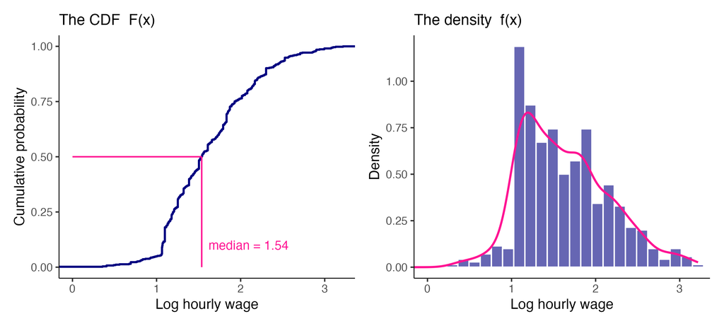

- Log hourly wages for 526 workers, drawn as an empirical CDF and as a density
- The pink guide on the left reads the median off the CDF backwards, from probability $0.5$ to the value

## Joint Distributions

A **joint distribution** describes two or more random variables at once.

The joint CDF of two random variables $X$ and $Y$ is

$$F_{X,Y}(x, y) = \Pr(X \le x,\ Y \le y)$$

If $X$ and $Y$ are continuous, the joint density is:

$$f_{X,Y}(x,y) = \frac{\partial^2}{\partial x \partial y} F_{X,Y}(x, y)$$

## Marginal and Conditional CDFs

The marginal CDF of $X$ is:

$$F_X(x) = \Pr(X \le x) = \int_{-\infty}^x f_X(t)\,dt$$

The conditional CDF of $Y$ given $X = x$ is:

$$F_{Y \mid X}(y \mid x) = \Pr(Y \le y \mid X = x) = \int_{-\infty}^y f_{Y \mid X}(t \mid x)\,dt$$

## Marginal and Conditional Densities

**Marginal** — integrate the other variable out and recover one variable on its own:

$$f_X(x) = \int f_{X,Y}(x, y)\,dy$$

**Conditional** — fix one variable and ask about the other:

$$f_{Y \mid X}(y \mid x) = \frac{f_{X,Y}(x, y)}{f_X(x)}$$

That is the same renormalizing move as $\Pr(A \mid B)$, now with densities.

## Independence

$X$ and $Y$ are **statistically independent** when the joint distribution or density factors into the marginals:

$$f_{X,Y}(x,y) = f_X(x)\,f_Y(y)
\qquad \text{equivalently} \qquad
f_{Y \mid X}(y \mid x) = f_Y(y)$$

## Probability and Statistics

**Probability** starts from a known $F$ and reasons forward to what the data might look like.

**Statistics** starts from realized data and reasons backward to what $F$ might be.

- We never see $F$. We see a sample of draws from it.
- The job is to use those draws to learn features of $F$, and to be honest about how uncertain the answer is
- “Population,” “DGP,” and “the truth” are all names for $F$

## Recap

- A **random variable** is a function on the sample space, and it is what we work with instead of $\Omega$
- The **CDF** is a complete description of a random variable; the density or mass function is the same information in slope form
- **Conditioning** renormalizes onto the event you were told about, and **Bayes’ rule** flips the direction of conditioning
- A **joint distribution** carries the relationship between variables
- $F$ is the population.